# Replication & Extension of Regional Favoritism

(Hodler & Raschky, 2014)

Author

Affiliation

Ömer Furkan Çoban

Carl von Ossietzky University of Oldenburg

Submitted

09 September 2026

Abstract

Hodler and Raschky (2014) find that a region grows brighter at night while it is the birth region of the sitting political leader, evidence of regional favoritism. This paper asks whether that finding survives being rebuilt rather than re-run: boundaries come from GADM rather than their CIESIN source, birthplaces from PLAD and a Wikidata supplement rather than their own geocoding, and light is extracted here from raw DMSP-OLS composites. On their exact 1992-2009 sample, seven of the eight columns of their Table II reproduce in sign and significance, with a birth-region coefficient of 0.032 against their 0.038, implying roughly one percent higher regional output per year of incumbency. Table IV’s spatial pattern reproduces as well, fading one grid step sooner. Extending the panel to 2023 on a harmonized DMSP/VIIRS series strengthens the result: all seven extended specifications are significant and the coefficient rises to 0.048. It also recovers the one column that fails on the original window, the extensive margin, suggesting that null reflects the DMSP sensor’s limits rather than a missing effect. Two discrepancies do not resolve: the population control enters with the opposite sign throughout, and the tightest spatial unit reverses their directional conclusion.

Keywords

Regional favoritism, Nighttime lights, Replication, Political economy, Geographic information systems

# 1 Introduction

A political leader’s home region gets measurably brighter at night, in satellite-recorded nighttime light data, while that leader holds power. This is the central empirical claim of Hodler & Raschky (2014), and it is a claim about a specific, testable channel of political favoritism: leaders steer public resources toward the region where they were born, not necessarily toward the region that needs them most.

Testing this directly with government spending data is difficult, and not by coincidence. Fiscal records at the subnational level are missing or unreliable in exactly the settings where regional favoritism is most likely to occur, in weak-institution states with limited budget transparency, so the evidence would be censored precisely where the effect is largest. Nighttime light intensity, measured by satellite, offers a way around this. It is recorded by the same instrument and the same method everywhere, it exists for every populated region regardless of what any government chooses to publish, and no domestic authority can edit or suppress it. It is, in short, an outcome a government cannot manipulate even if it wanted to, which makes it a credible proxy for local economic activity and infrastructure investment (Henderson et al., 2012).

Hodler & Raschky (2014) build on this logic with a global panel of 38,427 subnational regions across 126 countries, observed annually from 1992 to 2009, and estimate that a region becomes on average about four percent brighter while it is the birth region of the sitting political leader. The effect is strongest where institutions are weak and education is low, and it grows with the availability of foreign aid and oil rents, consistent with a story in which favoritism requires both a motive and the means to act on it.

What that average effect looks like in a single case is shown in Figure 1. Gôh, a region in central Ivory Coast, tracked the national average closely throughout the 1990s, then diverged sharply in 2000, the year Laurent Gbagbo, born in Gôh, took office as president: the region pulled away from the national trend and kept climbing over the following years, while the rest of the country stayed flat. The satellite images tell the same story spatially, with the lit area inside the region’s boundary thickening between 1996 and 2009. One region is of course not evidence on its own, and Gôh was selected precisely because it is a clear case; the point of the figure is to make concrete what the estimates in the rest of the paper measure on average across thousands of regions.

[figure not shown]

Figure 1: DMSP-OLS stable lights over Gôh, Ivory Coast, at four points in time, and the region’s nighttime light trend against the national average, 1992-2013. Laurent Gbagbo, born in Gôh, took office in 2000.

This paper’s contribution has three components: a replication of Table II, the main results and robustness battery; a replication of Table IV, the test of how the effect varies with the size of the geographic unit used to measure it; and an extension of the panel well beyond HR’s original 1992-2009 window. The replication is built on an independently constructed pipeline: the region-leader crosswalk, the birthplace coordinates, and the grid-cell geometry used for the geographic-extent test were all built from raw sources rather than reused from any existing processed panel. The headline finding survives this independent reconstruction. Seven of the eight Leader coefficients in Table II replicate in sign and statistical significance, and Table IV’s central pattern, that the effect shrinks steadily as the geographic unit of measurement grows larger and eventually becomes indistinguishable from zero, replicates as well, though the point at which it stops clearing conventional significance falls one grid step earlier here than in the authors’ own data. Section 5.1 reports the one Table II column that does not replicate, and Section 6 collects that alongside the paper’s other departures from the original. The extension, built on a harmonized DMSP/VIIRS nighttime-lights panel running through 2023 and an independently constructed population pipeline, asks whether the same effect holds over a substantially longer horizon than HR originally had available. It does, and it is larger rather than smaller: the birth-region coefficient rises from 0.032 on the replication window to 0.048 over 1992-2023, and the one specification that fails to replicate in the shorter window recovers once the more sensitive VIIRS sensor enters the series, which is reported in Section 5.3. Five additional HR tables the project replicated but that do not fit within this paper’s scope are reported separately in the Supplementary Materials.

# 2 Literature

Regional favoritism sits within a broader literature on distributive politics, the study of how governments allocate resources across constituencies for political rather than purely economic reasons. Prior to Hodler & Raschky (2014), this literature had relied almost entirely on single-country spending data (Golden & Min, 2013), leaving systematic, cross-country evidence of favoritism largely absent, in part because subnational fiscal records are themselves missing or unreliable in the settings where favoritism is most likely. Within that literature, a specific strand asks whether leaders favor the group or place they come from. Franck & Rainer (2012) show that in Sub-Saharan Africa, districts sharing the president’s ethnicity see better educational and health outcomes while that president is in power, evidence of ethnic rather than strictly regional favoritism. Hodler & Raschky (2014) ask the related but distinct question of whether favoritism attaches to a leader’s birth *region*, defined administratively rather than ethnically, and whether it is visible in a measure of economic activity rather than in public-service outcomes.

That measure is nighttime light intensity, whose use as a proxy for subnational economic activity is itself a distinct methodological contribution. Henderson et al. (2012) establish that satellite-recorded light is informative about output growth even where official statistics are weak or absent, precisely the setting in which government spending data cannot be trusted to reveal favoritism directly. Hodler & Raschky (2014)’s contribution is to combine this measurement tool with a global, leader-birthplace dataset (Goemans et al., 2009) and a within-country, within-year identification strategy, allowing regional favoritism to be tested at a scale and with a design no single-country study of distributive politics could match. More recently, Bora (2025) extend this approach into the higher-frequency VIIRS era and find that the effect appears immediately upon a leader taking office rather than with a lag, with a further premium during the COVID-19 pandemic concentrated in weaker democracies, a modern-era pattern this paper’s own extended window speaks to directly.

Against this backdrop, what this paper adds is less a new claim than a stress test of an existing one. Building the crosswalk, birthplace coordinates, and geometry independently, rather than reusing HR’s own processed panel, is what makes the result informative about how robust the finding is to reasonable implementation choices, not just about whether it replicates. Reporting where it does not fully hold up alongside where it does serves the same end: a literature’s confidence in a finding should rest on a complete account of the evidence, not only the parts that confirm it.

# 3 Data

## 3.1 Outcome: Nighttime Light Intensity

The dependent variable is DMSP-OLS stable lights (Earth Observation Group, Payne Institute for Public Policy, Colorado School of Mines, 2013), the same series the authors use. The raw signal comes from the Operational Linescan System carried on US Air Force Defense Meteorological Satellite Program satellites, a low-light sensor designed to image moonlit cloud cover at night that also happens to pick up artificial lighting on the ground. NOAA’s National Geophysical Data Center turns the raw passes into annual composites at 30 arc-second resolution (about 1 km at the equator), reporting a digital number from 0 to 63 for each grid cell. The stable-lights product used here is the cleaned version of that composite: cloud-contaminated observations are dropped, and ephemeral light sources, gas flares, fires, and other transient events, are filtered out by keeping only lights that appear consistently across the year, using NOAA’s own noise-floor thresholds for areas expected to be free of detectable light (Baugh et al., 2010), the same cleaning step the authors rely on. This is what makes the series suitable for measuring persistent infrastructure like electrification rather than one-off events. In years covered by two DMSP satellites, most of the panel, this project pixel-averages the two composites before extraction, matching the authors’ own convention of an annual composited mean across satellites; the country-year fixed effects described in Section 4 absorb any residual cross-satellite jump this leaves. Region-year values are the average digital number over each region’s area. Following the authors, every specification uses the log of light intensity plus a small constant, $\ln(\text{Light}_{ict} + 0.01)$, rather than the raw level. The constant is necessary because a large share of region-years, mostly rural areas with little or no artificial lighting, record a light value of exactly zero, and the log of zero is undefined; adding 0.01 before taking logs keeps those unlit region-years in the estimation sample instead of dropping them, at the cost of a mechanical floor on the transformed variable that has no substantive interpretation of its own. The authors report an analogous concentration in their own panel, 10.27% of observations at the lower bound and a further 0.85% at the sensor’s upper bound of 63, and cite the same log(+0.01) convention used here, following both Henderson et al. (2012) and Michalopoulos & Papaioannou (2013; see also Michalopoulos & Papaioannou, 2014). This paper’s own panel concentrates somewhat less at both ends, 9.18% at zero and 0.36% at the ceiling, consistent with a different boundary source placing somewhat fewer regions in either extreme rather than any difference in method.

## 3.2 Leader Birthplace

Each leader’s identity and tenure dates come from Archigos (Goemans et al., 2009), a cross-national dataset that records who ruled each country and over what dates; the authors use the same source for the same purpose. Archigos does not record every leader’s birthplace, so this project supplements it with the Political Leaders’ Affiliation Database (Bomprezzi et al., 2024) and, for leaders still missing after that merge, a manual Wikidata/Wikipedia scrape (Wikidata, 2026). Following the authors, leaders recorded as born outside the country they led are excluded from the `Leader` regressor rather than assigned a foreign birth region; the authors report that the leaders their own approach drops for missing birthplace information were, without exception but one, in office under 50 days (p. 1006, fn. 11), which is why that kind of exclusion is unlikely to matter much in either panel. The authors’ own birthplace-to-region match works differently from this replication’s: they geocode via CIESIN’s settlement-point shapefiles where a birth settlement can be identified, falling back to raw birthplace coordinates otherwise (p. 1006), whereas this project takes PLAD’s own already-geocoded region assignment directly, supplemented by the Wikidata coordinates described above. Of the 919 Archigos leader-spells overlapping this paper’s full 1992-2013 panel window (wider than the authors’ own 1992-2009 window, since this paper’s underlying panel extends further, as Section 5.3 uses), PLAD supplies a birthplace for 799 (86.9%); the Wikidata supplement resolves a further 33, bringing total coverage to 832 spells (90.5%). The remaining 87 spells (9.5%) stay uncovered, mostly leaders from 25 countries PLAD has no entry for at all, and are excluded from the `Leader` regressor rather than imputed. The regressor itself, `Leader`, is entered with a one-year lag rather than contemporaneously. The lag serves two purposes. First, a leader can take office at any point within a calendar year, so the contemporaneous year’s light reading is only partly observed under that leader; lagging one year guarantees the region was governed by the same leader for the entire period being measured. Second, favoritism plausibly operates through channels, such as infrastructure spending or electrification projects, that take time to build and are unlikely to be visible from space within the same year a leader takes office.

## 3.3 Geometry and Sample

The authors’ subnational regions come from CIESIN (CIESIN, Columbia University, 2005) (the Center for International Earth Science Information Network at Columbia University) and its project partners, at the second administrative level, and are not publicly redistributed as a standalone boundary file. This replication uses GADM 3.6 (GADM, 2018) instead, at every level of aggregation: the ADM2-level regions used for the main results and the ADM1-level geometry used in the geographic-extent test, both the full region and the hole-punched version with the leader’s home district cut out, are all built from the same GADM 3.6 vintage, so no crosswalk between geometry sources is needed anywhere in this replication. GADM 3.6 is not a reconstruction of the authors’ own CIESIN boundaries, which is a source of divergence between the two panels discussed further in Section 6. The estimation sample throughout the paper is restricted to the authors’ exact set of 126 countries observed over 1992-2009, applying the same two exclusion criteria they state (p. 1001): countries with average population below 500,000, and any region whose entire area lies above 65°N latitude (their own footnote names Canada, Finland, Iceland, Norway, Russia, Sweden, and Alaska as the countries this affects), so that every comparison to the authors’ own reported numbers is like for like rather than an artifact of a different underlying sample. The authors state a third criterion alongside these two, dropping “the few regions that are unpopulated” (p. 1001). Table I and Table II apply a proxy for it: a region is dropped if no population figure could be matched to it in any observed year, 85 of 38,559 regions (0.06% of region-years) in this sample. That proxy is not a verified match to the authors’ own concept, since a missing population match reflects either genuine depopulation or a gap in this project’s own population source reaching that region, and the two cannot be told apart from the data alone; it is applied anyway, for completeness against the authors’ three-part criterion, because doing so changes essentially nothing: every coefficient in Table 2 is unchanged to three decimals except Column (5), which moves by 0.001. Table IV’s alternative units of observation (5km circles, SN1 regions, grid cells) each aggregate population differently and have no equivalent exclusion built for them, so this third criterion is not extended there.

## 3.4 Population and Regional GDP

Two further datasets enter Table II’s Columns 7 and 8, not used elsewhere in the paper. Regional population, needed to construct per-capita light in Column 7 and as a control in Column 8, comes from CIESIN’s Gridded Population of the World, Version 4 (CIESIN, Columbia University, 2018), zonal-summed to the same ADM2 regions used for the outcome variable. Column 8’s dependent variable, regional GDP, is where this replication departs most directly from the authors’ own construction: the authors use a regional GDP dataset from Gennaioli et al. (2014), which is not publicly released. This paper substitutes G-Econ 4.0 (Nordhaus et al., 2006), a gridded regional output dataset aggregated to the same ADM2 regions, as the closest available public alternative. The two sources are not interchangeable in their construction, so Column 8’s results are reported as indicative rather than as a like-for-like replication of the authors’ own Column 8, a caveat carried through to Section 5.1.

## 3.5 Descriptive Statistics

Table 1 reports summary statistics for the two variables common to every specification in this paper, nighttime light intensity and the lagged birth-region dummy, next to the authors’ own reported numbers for the same variables, over the identical 126-country, 1992-2009 sample. Population and regional GDP, the two further variables introduced in Section 3.4, are used only in Table II’s Columns 7 and 8 and are not reported here, since the authors’ own descriptive statistics table does not cover them either. The two panels agree closely: mean light intensity and its dispersion are nearly identical, and the leader dummy’s mean, of order 0.004, matches almost exactly, consistent with only a small number of a country’s many regions being a sitting leader’s birth region in any given year. Leader birth regions are not a random draw from that pool: the authors report that, on average, they are 40% larger, five times more populous, and roughly twice as bright at night as other regions in their own sample (p. 1006), a pre-treatment imbalance the region and country-year fixed effects in Section 4 are what make the identification strategy hold up despite it. The same comparison on this paper’s own panel agrees on population and light but not on area: leader birth regions are 5.7 times more populous and 2.2 times as bright, both close to the authors’ figures, but only 21% larger by land area (3,755 km² average against 3,095 km² for other regions), not 40%, computed over every region in this sample (38,474 of 38,474) using its GADM 3.6 geometry directly, the same source used throughout Section 3.3. The obs. count differs by roughly 5% for light (655,234 vs. 690,495), which follows directly from using a different boundary source, as Section 3.3 describes: GADM’s ADM2 partition does not divide every country into exactly the same regions CIESIN’s does, so the two panels are built over a similar but not identical number of region-years.

Leader<sub>ict-1</sub> is where the two panels initially looked further apart than that boundary-source gap alone would explain, and checking why surfaced something worth reporting rather than smoothing over. As a lagged variable, Leader<sub>ict-1</sub> should in principle lose the panel’s first year, 1992, since that year’s value depends on who governed in 1991, one year before the panel begins. The authors’ own reported figures show no such loss: their Leader<sub>ict-1</sub> obs. count is exactly 690,495, identical to Light<sub>ict</sub>’s. This is not an error on their part; Archigos records leader identity for years before 1992 too, so the 1991 lag can be built from data outside the panel’s own stated window without dropping any 1992 region-years. This paper’s own pipeline did not follow that same convention: 1992’s lag was left missing rather than filled from 1991 data, which by itself accounted for most of Leader<sub>ict-1</sub>’s shortfall against Light<sub>ict</sub> (613,178 vs. 655,234, a gap much wider than the boundary-source gap on Light<sub>ict</sub> alone). Rebuilding the 1992 lag from PLAD and the Wikidata supplement’s pre-1992 leader-tenure records, the same convention the authors use, raises the observation count to 654,254, with the mean and standard deviation essentially unchanged. Table 1 reports this corrected figure, which matches Table 2’s Column (1) exactly, since both are built from the identical 126-country panel and the same lag-construction method; the small residual gap to Light<sub>ict</sub> is the ordinary GADM-vs-CIESIN boundary-count difference, not a further lag artifact.

Table 1: Descriptive statistics, region-year panel, 126 countries, 1992-2009. Light$_{ict}$ is $\ln(\text{Light intensity} + 0.01)$; Leader$_{ict-1}$ is the lagged birth-region dummy. Authors’ columns are the corresponding rows of their own reported descriptive statistics table.

| Variable | Authors (126 countries, 1992-2009) Obs. | Authors (126 countries, 1992-2009) Mean | Authors (126 countries, 1992-2009) SD | Authors (126 countries, 1992-2009) Min | Authors (126 countries, 1992-2009) Max | This Paper (same 126 countries, 1992-2009) Obs. | This Paper (same 126 countries, 1992-2009) Mean | This Paper (same 126 countries, 1992-2009) SD | This Paper (same 126 countries, 1992-2009) Min | This Paper (same 126 countries, 1992-2009) Max |
| --- | --- | --- | --- | --- | --- | --- | --- | --- | --- | --- |
| Light\(_{ict}\) | 690,495 | 0.050 | 2.482 | -4.605 | 4.143 | 655,234 | 0.097 | 2.456 | -4.605 | 4.143 |
| Leader\(_{ict-1}\) | 690,495 | 0.004 | 0.060 | 0.000 | 1.000 | 654,254 | 0.004 | 0.060 | 0.000 | 1.000 |

# 4 Empirical Framework

The main specification is a fixed-effects regression at the region-year level, the same one the authors use:

$$\text{Light}_{ict} = \alpha_i + \beta_{ct} + \gamma\,\text{Leader}_{ict-1} + \varepsilon_{ict}$$

$\text{Light}_{ict}$ is log nighttime light intensity for region $i$ in country $c$ in year $t$, and $\text{Leader}_{ict-1}$ is the lagged birth-region dummy described in Section 3.2. $\alpha_i$ is a region fixed effect: it absorbs everything time-invariant about a region, geography, permanent infrastructure, its baseline level of development, so that $\gamma$ is not picking up the fact that some regions are simply always brighter than others regardless of who governs. $\beta_{ct}$ is a country-by-year fixed effect: it absorbs every shock common to all of a country’s regions in a given year, a national election, a currency crisis, a change in the electrification budget, so that $\gamma$ is not picking up nationwide light growth or decline that happens to coincide with a leadership change. It also absorbs a source of variation specific to satellite-recorded light: DMSP-OLS composites are built from different satellites in different years, each with its own sensor calibration, and any resulting jump or drift in recorded brightness is common to every region observed in that year and is absorbed by $\beta_{ct}$ along with everything else nationwide. What survives after both sets of fixed effects are partialed out is variation within a region, within a country-year: whether a given region gets brighter relative to the rest of its own country in the same year, right when it becomes the leader’s birth region. This is also why the specification does not need a set of country or year fixed effects on their own; the country-by-year interaction subsumes both.

$\gamma$ is the coefficient of interest. A positive, statistically significant $\gamma$ is read as evidence of regional favoritism: the birth region becomes disproportionately brighter than the rest of its own country, in the same year, precisely while it is a sitting leader’s home region. The authors expect and find $\gamma > 0$; this paper’s replication asks whether that same sign and significance survive an independently rebuilt version of every input the equation depends on.

Standard errors are clustered by leader spell, using Archigos (Goemans et al., 2009) to group all region-year observations under the same leader’s tenure together, following the authors’ own convention. Because $\text{Leader}_{ict-1}$ only changes value when a country’s leader changes, region-year observations within a single leader’s spell are not independent draws, and clustering at the country or region level alone would understate the true correlation in $\varepsilon_{ict}$ across the years any one leader stays in power. The cluster definition itself is lagged by one period, the same way $\text{Leader}_{ict-1}$ is, so that a country-year is grouped with the spell of the leader who was actually in power the year the regressor refers to, not the leader in power in the year being clustered.

# 5 Results

## 5.1 Main Results and Robustness (Table II)

Table 2 reports this paper’s own estimate of every column of Table II next to the authors’ published numbers, both estimated on the identical 126-country, 1992-2009 sample described in Section 3.3, so region and observation counts are directly comparable column by column rather than only in sign and significance. Every lagged column here also carries the same boundary-lag fix documented in Section 3.5 for Leader<sub>ict-1</sub> itself: 1992’s lag is filled from PLAD and the Wikidata supplement’s pre-1992 leader-tenure records rather than left missing, recovering 1992 as an estimation year in every column that uses the one-year lag. This raises Column (1)‘s observation count to 654,254, close to the authors’ own 690,495 and well above the 613,178 the same specification would show without the fix, but it also shifts every affected coefficient, and not uniformly toward the authors’ own numbers.

Column (1), the headline specification, the equation of Section 4 estimated exactly as written, gives a birth-region coefficient of 0.032, significant at the 5% level, against the authors’ own 0.038 at the 1% level: the boundary-lag fix moved this coefficient down from 0.037 (obtained without the fix) rather than up, a weaker match to the authors’ own number despite being the more methodologically correct specification.

What that coefficient means in economic terms follows the authors’ own translation. Because the dependent variable is in logs and Leader<sub>ict-1</sub> is a dummy, the implied effect on light is $100(\exp(\gamma) - 1)$ percent: a region is that much brighter while it is the sitting leader’s birth region than the same region would be if the leader had been born elsewhere. The authors’ $\gamma = 0.038$ gives 3.9%; the 0.032 estimated here gives **3.2%**. To get from light to output the authors use the light-GDP elasticity of roughly 0.3 that Henderson et al. (2012) estimate at the country level and that the authors confirm at the regional level, which turns their 3.9% into a **1.2%** increase in regional GDP and this paper’s 3.2% into **1.0%**. So the two panels disagree about the size of the favoritism premium by roughly a fifth, and agree that it is on the order of one percent of regional GDP per year of incumbency, concentrated in a single subnational region. That is small enough to be invisible in national accounts and large enough to matter locally, and, as the authors note, it is a lower bound on favoritism itself: leaders who direct resources somewhere other than their own birth region, or to areas larger or smaller than one administrative unit, register in this design as nothing at all.

Columns (2) and (3) exist, in the authors’ words, to ensure the main result “is not an artifact of the lag structure,” replacing the one-year lag with the contemporaneous dummy and a two-year lag respectively. That robustness holds here too, though unevenly: Column (3) replicates closely (0.040 against the authors’ 0.041, both significant at the 5% level or better), while Column (2) is the weaker of the pair at 0.029, significant only at the 10% level against the authors’ own 0.039 at the 1% level.

Columns (4) and (5) are a matched pair, and the authors are explicit about why. Adding the lagged dependent variable in Column (4) makes the specification vulnerable to Nickell bias, so, following Angrist & Pischke (2009), they estimate one specification with fixed effects but no lagged dependent variable (Column 1) and one with the lagged dependent variable but no region fixed effects (Column 5), and appeal to the bracketing property: the true effect should lie between the two. Their own estimates satisfy it, 0.019 in Column (4) and 0.061 in Column (5) around a main estimate of 0.038, which is what licenses their claim that the headline coefficient is “rather conservative and may even underestimate the true effect.” The same bracket holds in this replication, and independently: 0.026 in Column (4) and 0.050 in Column (5), with the main estimate of 0.032 sitting inside them. This is arguably the single strongest form of agreement between the two panels, because it reproduces not a number but a structural property of the estimates, and it means the conservative reading the authors put on their headline coefficient survives here as well.

Column (6), the extensive margin, restricts the outcome to $\ln(\text{Light}_{ict})$ without the additive constant, dropping region-years with zero recorded light entirely. The authors report that the coefficient “becomes somewhat smaller but remains statistically significant.” Here it does not: it falls to 0.008 and loses significance altogether, against their 0.029 at the 1% level. This is the clearest genuine non-replication in Table II, and also the column most affected by the boundary-lag fix. Substantively, it says the effect found here is carried by regions that were already lit and became brighter, rather than by dark regions crossing into visibility; the authors’ data supports both channels, this panel’s supports only the first. Section 6 returns to it.

Columns (7) and (8) change the dependent variable rather than the specification, and both replicate in sign and significance. Column (7) uses light per capita, controlling for regional population, which distinguishes a region getting brighter because more was built in it from a region getting brighter because more people moved into it. The estimate here is 0.025, against the authors’ 0.062. The gap is not only one of magnitude but of direction relative to the baseline: in the authors’ data the per-capita coefficient comes out *larger* than their main estimate of 0.038, which is what lets them argue the headline effect is not a population artifact, whereas here it is *smaller* than the corresponding 0.032. The population denominator differs between the two panels, GPWv4 here against the authors’ own CIESIN vintage (Section 3.4), and Section 6 returns to the sign flip on Pop<sub>ict</sub> itself that accompanies this.

Column (8) replaces light with regional GDP per capita directly, and is the one column that is not a like-for-like replication by construction: the authors use Gennaioli et al. (2014), which was never publicly released, so G-Econ 4.0 stands in for it here (Section 3.4). The estimate is 0.013 against their 0.021, both significant. What makes this column valuable despite the substitution is that it does not rely on the light-GDP elasticity at all. Where Column (1) reaches output indirectly, 3.2% more light times an assumed elasticity of 0.3, giving about 1.0%, Column (8) measures it directly and returns 1.3% on GDP per capita. The two are not the same quantity, one is regional output and the other output per person, so they need not coincide exactly; what matters is that two routes resting on entirely different data and assumptions both land near one percent rather than near ten or near zero. The same holds in the authors’ data, where the indirect route gives 1.2% and the direct route 2.1%.

Taken as a whole, seven of Table II’s eight columns replicate the authors’ finding in both sign and statistical significance on the identical sample; Column (2) does so only at the 10% level against their 1%, and Column (6) does not replicate at conventional significance levels at all. The qualitative conclusions the authors draw from this table survive: the effect is not an artifact of lag choice, it is bracketed from both sides in the Angrist-Pischke sense and therefore plausibly conservative, and it holds when output is measured directly rather than inferred from light. What does not survive is the extensive margin, and the per-capita result holds in a weaker form than in the authors’ own data.

Table 2: Table II replication, all eight columns, in HR 2014’s own layout. Both the Orig. and Repl. columns are estimated on the authors’ exact 126-country, 1992-2009 sample.

|  | (1) Light\(_{ict}\) Orig. | (1) Light\(_{ict}\) Repl. | (2) Light\(_{ict}\) Orig. | (2) Light\(_{ict}\) Repl. | (3) Light\(_{ict}\) Orig. | (3) Light\(_{ict}\) Repl. | (4) Light\(_{ict}\) Orig. | (4) Light\(_{ict}\) Repl. | (5) Light\(_{ict}\) Orig. | (5) Light\(_{ict}\) Repl. | (6) Light0\(_{ict}\) Orig. | (6) Light0\(_{ict}\) Repl. | (7) Lightpc\(_{ict}\) Orig. | (7) Lightpc\(_{ict}\) Repl. | (8) RegionalGDP\(_{ict}\) Orig. | (8) RegionalGDP\(_{ict}\) Repl. |
| --- | --- | --- | --- | --- | --- | --- | --- | --- | --- | --- | --- | --- | --- | --- | --- | --- |
| Leader\(_{ict-1}\) | 0.038*** (0.014) | 0.032** (0.015) |  |  |  |  | 0.019*** (0.010) | 0.026*** (0.010) | 0.061*** (0.010) | 0.050*** (0.008) | 0.029*** (0.013) | 0.008 (0.012) | 0.062*** (0.024) | 0.025** (0.011) | 0.021*** (0.006) | 0.013** (0.006) |
| Leader\(_{ict}\) |  |  | 0.039*** (0.015) | 0.029* (0.016) |  |  |  |  |  |  |  |  |  |  |  |  |
| Leader\(_{ict-2}\) |  |  |  |  | 0.041*** (0.013) | 0.040*** (0.015) |  |  |  |  |  |  |  |  |  |  |
| Light\(_{ict-1}\) |  |  |  |  |  |  | 0.400*** (0.023) | 0.408*** (0.025) | 0.962*** (0.004) | 0.964*** (0.004) |  |  |  |  |  |  |
| Pop\(_{ict}\) |  |  |  |  |  |  |  |  |  |  |  |  | 0.958*** (0.066) | -0.714*** (0.067) | 0.201*** (0.049) | -0.007* (0.004) |
| Number of regions | 38,427 | 38,474 | 38,427 | 38,474 | 38,427 | 38,474 | 38,427 | 38,474 | 38,427 | 38,474 | 36,591 | 37,179 | 37,475 | 38,474 | 1,207 | 6,531 |
| Observations | 690,495 | 654,254 | 690,495 | 655,234 | 689,870 | 578,100 | 652,362 | 616,760 | 652,362 | 616,760 | 619,594 | 593,814 | 673,382 | 654,254 | 14,995 | 113,110 |
| Within R\(^{2}\) | 0.319 | 0.314 | 0.319 | 0.315 | 0.318 | 0.239 | 0.412 | 0.398 | 0.964 | 0.969 | 0.393 | 0.350 | 0.197 | 0.418 | 0.653 | 0.803 |
| Region FE | Yes | Yes | Yes | Yes | Yes | Yes | Yes | Yes | No | No | Yes | Yes | Yes | Yes | Yes | Yes |
| Country-Year FE | Yes | Yes | Yes | Yes | Yes | Yes | Yes | Yes | Yes | Yes | Yes | Yes | Yes | Yes | Yes | Yes |

*Notes.* Fixed-effect regressions, except Column (5), which is standard OLS, using annual data for subnational regions between 1992 and 2009. Light\(_{ict}\) is the log of average nighttime light intensity plus 0.01. Light0\(_{ict}\) is the log of average nighttime light intensity, without adding a constant. Lightpc\(_{ict}\) is the log of nighttime light intensity per capita plus 0.01. RegionalGDP\(_{ict}\) is the log of regional GDP per capita, G-Econ 4.0 in the Repl. columns, substituting for the authors' unreleased Gennaioli et al. (2014) source (Section 3.4). Leader\(_{ict}\) is a dummy variable equal to 1 if region i is the birth region of the political leader in country c in year t, and 0 otherwise; the Repl. columns' Leader\(_{ict-1}\) additionally carries the boundary-lag fix documented in Section 3.5, filling 1992 from pre-1992 leader-tenure records rather than dropping it. Pop\(_{ict}\) is the log of regional population. Standard errors, in parentheses, are clustered by leader spell, lagged one period. \(^{***}\), \(^{**}\), \(^{*}\) indicate significance at the 1%, 5%, and 10% levels, respectively.

## 5.2 Geographic Extent (Table IV)

Table IV asks a different question than Table II: not whether the birth-region effect exists, but how far it extends. Each of the seven columns keeps the same specification and re-runs it on a different definition of “region,” shrinking or coarsening the spatial unit without changing anything else. Figure 2 shows what those units actually look like on the ground, drawn on one real birthplace, Recep Tayyip Erdoğan’s, in Kasımpaşa on Istanbul’s Golden Horn, rather than described in the abstract. Panel A is Column (1): a 5 km circle around the birth coordinate, clipped to the coastline, the tightest unit in the table, 58 km² here once the Golden Horn is cut out of it. Panel B is Column (2): the whole SN1 region, here Istanbul province at 4,757 km², about eighty times the circle. Panel C is Column (3): the same SN1 region with the birth district, Beyoğlu, cut out of the light average, 10 km² against the province’s 4,757, a hole small enough that the panel carries an inset to make it visible. In estimation the same cut is applied to every district that was ever a birthplace, not only the one drawn here. Panel D is Columns (4)-(7): the four grid cells containing the same point, at 50, 100, 200, and 400 km, drawn together so the jump in unit size across those four columns is visible at once. These are equal-area rather than equal-sided cells, so the nominal 50 km cell covers exactly 2,500 km² but measures 38 by 66 km at this latitude; the panel draws them uncut, whereas the estimation averages light only over the part of each cell that falls on land, which this close to the Bosphorus discards most of it. Because the four units differ in area by about four orders of magnitude, each panel is zoomed to its own unit and carries its own scale bar. All four are built from this project’s own geometry pipeline, using the same GADM 3.6 boundaries, hole-punch procedure, and grid construction that produce the estimates in Table 3, not schematic illustrations.

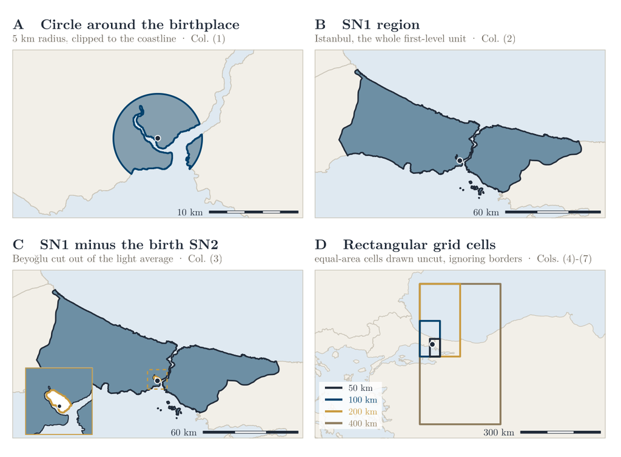

Figure 2: The four units of observation behind Table IV, drawn on Recep Tayyip Erdoğan’s birthplace (28.968°E, 41.032°N). Panels are zoomed independently and each carries its own scale bar; the inset in Panel C magnifies the removed birth district. Geometry comes from this project’s own pipeline, except Panel A’s circle, redrawn as a smooth 5 km buffer on the same coastline because the stored geodesic buffer’s boundary approximation shows at this magnification.

Table 3: Table IV replication, all seven columns, both panels on the authors’ exact 126-country, 1992-2009 sample. Dependent variable: Light$_{ict}$ throughout. Standard errors in parentheses, clustered by leader spell lagged one period. Units of observation: Col. 1, 5 km circles around the leader’s birthplace; Col. 2, SN1 (ADM1) region; Col. 3, SN1 with the birth SN2 (ADM2) district excluded; Cols. 4-7, an equal-area world grid at 50/100/200/400 km resolution.

|  | (1) Light\(_{ict}\) Orig. | (1) Light\(_{ict}\) Repl. | (2) Light\(_{ict}\) Orig. | (2) Light\(_{ict}\) Repl. | (3) Light\(_{ict}\) Orig. | (3) Light\(_{ict}\) Repl. | (4) Light\(_{ict}\) Orig. | (4) Light\(_{ict}\) Repl. | (5) Light\(_{ict}\) Orig. | (5) Light\(_{ict}\) Repl. | (6) Light\(_{ict}\) Orig. | (6) Light\(_{ict}\) Repl. | (7) Light\(_{ict}\) Orig. | (7) Light\(_{ict}\) Repl. |
| --- | --- | --- | --- | --- | --- | --- | --- | --- | --- | --- | --- | --- | --- | --- |
| Leader\(_{ict-1}\) | 0.049** (0.024) | 0.024 (0.020) | 0.026** (0.010) | 0.017 (0.011) | 0.023** (0.012) | 0.010 (0.012) | 0.043*** (0.010) | 0.036*** (0.012) | 0.028** (0.011) | 0.019* (0.011) | 0.020** (0.009) | -0.001 (0.009) | 0.005 (0.009) | -0.004 (0.008) |
| Units of observation | 5 km circle |  | SN1 region |  | SN1, excl. birth SN2 |  | 50 km grid |  | 100 km grid |  | 200 km grid |  | 400 km grid |  |
| Observations | 9,134 | 11,522 | 40,157 | 40,936 | 39,761 | 40,936 | 1,048,370 | 988,347 | 280,210 | 286,650 | 101,655 | 91,132 | 35,889 | 32,547 |
| Within R\(^{2}\) | 0.520 | 0.493 | 0.602 | 0.649 | 0.603 | 0.644 | 0.210 | 0.299 | 0.298 | 0.350 | 0.362 | 0.396 | 0.449 | 0.478 |
| Region FE | Yes | Yes | Yes | Yes | Yes | Yes | Yes | Yes | Yes | Yes | Yes | Yes | Yes | Yes |
| Country-Year FE | Yes | Yes | Yes | Yes | Yes | Yes | Yes | Yes | Yes | Yes | Yes | Yes | Yes | Yes |

*Notes.* Fixed-effect regressions using annual data for subnational regions between 1992 and 2009. Light\(_{ict}\) is the log of average nighttime light intensity plus 0.01. Leader\(_{ict}\) is a dummy variable equal to 1 if region i is the birth region of the political leader in country c in year t, and 0 otherwise. Standard errors, in parentheses, are clustered by leader spell, lagged one period. Units of observation differ across columns as labeled in the table. \(^{***}\), \(^{**}\), \(^{*}\) indicate significance at the 1%, 5%, and 10% levels, respectively.

The economic question behind this table is stated plainly by the authors: are the beneficiaries of favoritism “the political leaders’ family and clan members living in rather narrow geographical areas around the political leaders’ birthplace, or many people in relatively large geographical areas?” A narrow, clan-sized effect and a broad, province-sized one look identical in Table II, which fixes the unit at ADM2 and cannot distinguish them. Varying the unit separates them, and the answer matters for what regional favoritism is: patronage delivered to a leader’s immediate circle, or public investment whose incidence, whatever its motive, reaches a substantial population.

Columns (4) through (7) replace administrative units with a same-sized rectangular grid. The authors are explicit that this serves two purposes: tracing how far the effect reaches, and showing that “our previous results are not an artifact of the different sizes and shapes of subnational administrative regions across the world,” a modifiable-areal-unit check. That check passes cleanly in both panels, and is the strongest agreement in this table: at 50 km, the resolution closest in scale to an ADM2 district, the grid returns 0.036 here against an ADM2 baseline of 0.032, and 0.043 against 0.038 for the authors. Two entirely different partitions of the same territory, one drawn by governments and one drawn by an arbitrary lattice, recover the same effect to within a few thousandths.

Where the panels part company is how far out the effect persists. The authors report it significant at 50, 100, and 200 km and only fading at 400 km. Here it is significant at 50 km (0.036) and 100 km (0.019) and gone by 200 km. A more informative way to read the decline than significance alone is to ask how fast it falls. Each step up the grid quadruples cell area, so a purely local effect, a fixed absolute increment of light confined to one spot, would be diluted across four times the area and its coefficient should fall by a factor of four. Anything slower means the effect genuinely occupies the larger cell. By that benchmark the authors’ effect keeps extending through 200 km (their 100 km coefficient of 0.028 far exceeds the 0.011 that pure dilution predicts, and 200 km’s 0.020 exceeds 0.007), and only at the 200-to-400 km step does it decay at exactly the dilution rate, 0.005 predicted against 0.005 observed, marking the outer edge of the footprint. This panel’s effect also extends past 50 km (0.019 against a predicted 0.009) but then decays *faster* than dilution from 100 km onward, placing its outer edge somewhere between 100 and 200 km.

In economic terms the two panels agree on the shape and disagree on the reach. Converting as in Section 5.1, the authors’ 50 km estimate is 4.4% more light, or about 1.3% more regional output; this paper’s is 3.6% and 1.1%. At 100 km both fall to roughly 2-3% light and 0.6-0.9% output. So the per-area intensity of favoritism declines steadily outward in both, which is what one expects if resources are concentrated near the leader’s home and thin out with distance rather than being spread evenly across a province. The substantive difference is the size of the area over which that premium is detectable at all: on the authors’ data, a footprint extending to a few hundred kilometres and therefore plausibly covering millions of people; on this data, a tighter footprint of roughly 100 km. Both readings are inconsistent with favoritism as pure clan-level transfer, since a 50 km cell already covers 2,500 km², far more than a family or a village. Where the authors’ evidence supports the stronger claim that a substantial share of the benefit reaches large populations well beyond the birth district, this replication supports it only in weakened form.

## 5.3 Extension to the 1992-2023 Window

The authors’ window closes in 2009 because that is where their data ends, not because anything about the question does. DMSP-OLS runs through 2013 and VIIRS begins in 2012, so a harmonized series (Li et al., 2020) that splices the two roughly doubles the usable span to 1992-2023. This section re-estimates Columns (1) through (7) of Table II on that longer panel. Column (8) is not extended, since it depends on G-Econ regional GDP, which does not run past the replication window.

Three things change besides the years: the light series, the population source, and the clustering. Two of the three carry directly into how the results should be read, so they are set out first.

### 5.3.1 Data behind the extension

**Nighttime lights.** The outcome is the harmonized DMSP/VIIRS series of Li et al. (2020), which applies the stepwise inter-satellite calibration of Li & Zhou (2017) to produce one continuous global panel from 1992 onward. Its two halves have different origins: 1992-2013 is inter-calibrated DMSP-OLS, and 2014 onward is VIIRS converted onto DMSP’s own 0-63 digital-number scale, so that the two are directly comparable in levels. Both halves share 30 arc-second resolution and WGS84, matching the raw DMSP composites used in Section 3.1. This project extracted region-year zonal means from the rasters itself, over the same GADM 3.6 geometry used for the ADM2 replication geometry in Section 3.3, giving 1.51 million region-years across 45,913 regions in 174 countries; 99.1% of those rows are ADM2, with ADM1 used only for countries GADM 3.6 gives no ADM2 breakdown for. The source authors suggest treating digital numbers at or below 7 as a noise floor; this paper does not apply that filter, keeping the raw zonal mean and following the same convention as the replication panel, where thresholds are an analysis choice rather than something baked into extraction.

The conversion direction matters for reading Column (6). Because VIIRS is mapped *onto* DMSP’s scale rather than the reverse, the harmonized series does not inherit VIIRS’s full dynamic range, and one might expect the extensive margin to behave the same in both halves. It does not: the VIIRS half records zero light in 4.1% of region-years against 9.4% in the DMSP half. Even after compression onto a 0-63 scale, in other words, the later sensor still resolves faint light that the earlier one recorded as darkness, which is what makes the extensive-margin recovery interpretable as a sensor effect rather than a change in the phenomenon.

**Population.** Column (7) needs annual regional population over the full window, which no source provides directly. GHS-POP (Schiavina et al., 2023) publishes benchmarks every five years, and this project computed zonal population sums for 1990, 1995, 2000, 2005, 2010, 2015 and 2020 over the same ADM2 geometry, then interpolated linearly between consecutive benchmarks in levels rather than logs, after aggregation to the region rather than on the raster. The result covers 45,962 regions in 166 countries.

One limitation is worth stating rather than burying. The last benchmark used here is 2020, so values for 2021-2023 are not interpolated between two observed anchors; they are held flat at the 2020 level. Those three years are the weakest part of the population series, and Column (7) is the only column that depends on it. Because that is a real weakness, it was tested rather than assumed harmless: re-estimating Column (7) on 1992-2020, which drops the flat tail entirely, and again on 1992-2015, where every year lies between two observed benchmarks, moves the birth-region coefficient by less than 0.002 and changes no conclusion. Three flat years at the end of a 32-year panel are not what identifies this specification.

A second point about units belongs here, since it materially affected an earlier version of these results. Population enters twice, once as the denominator of per capita light and once as a control, and HR define it in thousands. The interpolated GHS-POP file stores its `lnpop` column on that scale but its raw count column in persons, and an early version of the extension code took the denominator from the latter. Dividing light by population in persons makes the ratio of order $10^{-4}$, small enough that the additive constant of 0.01 in $\ln(\text{Light}/\text{Pop} + 0.01)$ dominates it: the dependent variable’s standard deviation fell from 1.81 to 0.26 and Column (7) was driven to 0.001 and insignificance. The results reported here use population in thousands throughout, consistent with the replication panel and with the authors’ own definition.

**Leaders and clustering.** Birthplaces come from the same PLAD and Wikidata sources as the replication (Section 3.2), expanded across the longer window. Clustering, however, cannot follow the replication’s convention: Archigos 4.1 stops recording leader spells in 2015, so leader-spell clusters are undefined for roughly a third of the extension window. Standard errors are therefore clustered at the country level throughout the extension. This is the more conservative choice of the two available, since country clusters are strictly coarser than leader-spell clusters, and it is applied to all seven columns rather than only the later years, so that the columns remain comparable to each other.

### 5.3.2 Results over the extended window

Table 4 reports the results. The headline finding is that the effect does not fade over the longer horizon; it grows. Column (1) rises from 0.032 on the replication window to 0.048 over 1992-2023, significant at the 1% level on roughly 1.3 million region-years across 45,463 regions. In the terms of Section 5.1 that is 4.9% more light, or about 1.5% more regional output, against 3.2% and 1.0% on the shorter window, and it also exceeds the authors’ own 1992-2009 estimate of 3.9% and 1.2%. The lag-robustness columns move with it, 0.043 contemporaneous and 0.046 at two years, and the Angrist-Pischke bracket that held in Section 5.1 holds here too, with Column (4) at 0.025 and Column (5) at 0.074 straddling the main estimate.

Table 4: Extension: HR 2014 Table II, Columns (1)-(7), re-estimated on the harmonized DMSP/VIIRS panel over 1992-2023. Column (8) is not extended, since G-Econ regional GDP does not cover the later window.

|  | Light\(_{ict}\) (1) | Light\(_{ict}\) (2) | Light\(_{ict}\) (3) | Light\(_{ict}\) (4) | Light\(_{ict}\) (5) | Light0\(_{ict}\) (6) | Lightpc\(_{ict}\) (7) |
| --- | --- | --- | --- | --- | --- | --- | --- |
| Leader\(_{ict-1}\) | 0.048*** (0.017) |  |  | 0.025** (0.010) | 0.074*** (0.016) | 0.035** (0.016) | 0.026*** (0.009) |
| Leader\(_{ict}\) |  | 0.043** (0.017) |  |  |  |  |  |
| Leader\(_{ict-2}\) |  |  | 0.046** (0.018) |  |  |  |  |
| Light\(_{ict-1}\) |  |  |  | 0.556*** (0.026) | 0.943*** (0.009) |  |  |
| Pop\(_{ict}\) |  |  |  |  |  |  | -0.534*** (0.058) |
| Number of regions | 45,463 | 45,463 | 45,463 | 45,463 | 45,463 | 45,133 | 45,386 |
| Observations | 1,301,050 | 1,360,509 | 1,274,892 | 1,260,294 | 1,260,314 | 1,186,109 | 1,298,598 |
| Within R\(\(^{2}\)\) | 0.516 | 0.461 | 0.435 | 0.634 | 0.945 | 0.604 | 0.472 |
| Region FE | Yes | Yes | Yes | Yes | No | Yes | Yes |
| Country-Year FE | Yes | Yes | Yes | Yes | Yes | Yes | Yes |

*Notes.* Fixed-effect regressions, except Column (5), which is standard OLS, using annual data for subnational regions between 1992 and 2023 on the harmonized DMSP/VIIRS series of Li et al. (2020). The dependent variable is given in the column header: Light\(_{ict}\) is the log of average nighttime light intensity plus 0.01, Light0\(_{ict}\) omits the additive constant, and Lightpc\(_{ict}\) is per capita. Leader\(_{ict}\) is a dummy equal to 1 if region i is the birth region of the political leader in country c in year t, entered contemporaneously in Column (2), at a two-year lag in Column (3), and at a one-year lag elsewhere. Light\(_{ict-1}\) is lagged light and Pop\(_{ict}\) is the log of regional population from this project's own GHS-POP series. Standard errors, in parentheses, are clustered at the country level, since Archigos 4.1 does not define leader spells past 2015. Within R^2 follows the same region-demeaned convention as Tables 2 and 3; Column (5) reports full R^2, having no region fixed effects to demean by. \(^{***}\), \(^{**}\), \(^{*}\) indicate significance at the 1%, 5%, and 10% levels, respectively.

Two columns deserve separate comment: the one that changes most between the windows, and the one that changes least.

Column (6), the extensive margin, is the specification that failed to replicate on the authors’ own window, where it fell to 0.008 and lost significance. Over the extended panel it recovers: 0.035, significant at the 5% level. This is worth stating plainly because it revises what Section 5.1 could conclude on its own. There the failure looked like a fragility in the finding; here it looks more like a limitation of the instrument. DMSP-OLS is comparatively insensitive at low luminance, so genuinely faint regions are recorded as exact zeros and drop out of a specification that logs light without an additive constant. The zero rate in the harmonized series bears this out: 9.4% of region-years in its DMSP half against 4.1% in its VIIRS half (Section 5.3.1). The extensive margin reappearing once VIIRS enters the series is therefore consistent with many of the DMSP-era zeros having been a sensor floor rather than true darkness. The window and the sensor do change together here, so this panel cannot fully separate them, but the zero counts point at the sensor.

Column (7), per capita light, gives 0.026 over the extended window against 0.025 on the replication window, which is about as close an agreement as any column in this paper produces. That is worth underlining because the two estimates share almost nothing on the input side: different light series, different population source (GPWv4 against GHS-POP), different window, different clustering. The per-capita result is the one Section 5.1 flagged as weaker than the authors’ own, and it is also the one whose population control carries a sign this paper cannot match to theirs (Section 6). Both of those remain true; what the extension adds is that the birth-region coefficient itself is stable across two largely independent constructions of the same specification.

In economic terms, converting as in Section 5.1, the favoritism premium is roughly half again as large over the longer window as over the replication window. Column (1)‘s 0.048 is 4.9% more light, or about 1.5% more regional output per year of incumbency, against 3.2% and 1.0% on 1992-2009, and above the authors’ own 3.9% and 1.2%. The other columns bracket that figure the way one would expect rather than scattering: the demanding dynamic specification in Column (4) puts the floor at 2.5% light and 0.75% output, the no-region-fixed-effects specification in Column (5) puts the ceiling at 7.7% and 2.3%, and the ratio between ceiling and floor is 3.0 here against 1.9 on the replication window (Column (4)’s 0.026 and Column (5)’s 0.050 there), so the bracket has widened somewhat as the panel has doubled in length, driven by Column (5)’s larger coefficient rather than any change at the floor. Column (7), which measures the same thing per person rather than per region, gives 2.7% against 2.5% on the shorter window. Read together, the estimates say that a region gains on the order of one to one and a half percent of output in each year its native son or daughter holds office, and that this figure is if anything a little larger in the 2010s and 2020s than it was in the 1990s.

Whether that increase reflects more favoritism or better measurement is not settled by this panel. The rise is concentrated in exactly the columns where the sensor change should matter most, and Column (4), the one column whose identification leans on within-region dynamics rather than levels, is also the one column that does not rise at all, holding at 0.025 against 0.026 on the replication window. That pattern is at least as consistent with VIIRS resolving light that DMSP missed as with leaders having become more generous to their birthplaces. What the extension does establish is the negative claim, and it is the one that matters for the paper’s purpose: the effect is not an artifact of the window the authors happened to have data for.

Taken together, the extension says the birth-region effect is not an artifact of the 1992-2009 window. All seven extended columns are significant, the effect is larger rather than smaller over the longer period, and the one column that failed in the replication recovers once a more sensitive sensor is in the series.

# 6 Discussion and Limitations

Four results in this paper depart from the authors’, and each is reported where it arises. This section does not restate them. It asks what each departure should do to a reader’s confidence in the underlying finding, which is a different question and, for a replication, the more important one.

**A null that belongs to the instrument.** The extensive margin is the one Table II column that fails outright on the replication window, and taken alone it would be the paper’s most damaging result. The extension changes what it can mean. Recovering the same specification on a series with a more sensitive sensor, alongside a halving of the region-years recorded as perfectly dark, points to the DMSP-era zeros being a detection floor rather than genuine darkness (Section 5.3.1). The caution is that window and sensor move together in the extension, so this is an interpretation the data permit rather than one it forces. Read conservatively, the column should be treated as uninformative on 1992-2009 rather than as evidence against favoritism.

**A discrepancy this paper cannot explain.** The population control enters with the opposite sign to the authors’ in every specification that includes it, across two population products and both windows. Stability across independent sources makes a coding error on this side unlikely, but nothing here identifies the cause, and it would be dishonest to present a guess as a finding. What limits the damage is that Pop is a control rather than the estimand, and that the birth-region coefficients in the columns carrying it agree closely with each other. The appropriate response is not to discount the paper’s estimates but to treat Columns (7) and (8) as its least settled, and the population question as open.

**A substitution, not a replication.** Column (8) uses G-Econ in place of the authors’ unreleased regional GDP source, over a sample several times larger. That the two land at a similar output magnitude is corroboration from an independent direction; it is not evidence that the two series measure the same quantity at the region level, and the column should not be counted as a replicated result.

**A difference that cannot be removed.** The authors’ regions come from CIESIN and this paper’s from GADM, so the two panels never partition countries identically. This is the most likely source of the small, uniform differences running through the replication columns, and it means no result here is a strict recomputation. Every comparison in this paper is between two constructions of the same design, which is the point of the exercise but also its ceiling: a gap of a few thousandths is not attributable to anything in particular.

# 7 Conclusion

This paper set out to test whether Hodler & Raschky (2014)’s finding survives being rebuilt rather than re-run. Nothing was inherited from their processed panel: the boundaries come from GADM rather than CIESIN, the birthplaces from PLAD and a Wikidata supplement rather than their own geocoding, and the light values from raw satellite composites extracted here. On that independently assembled data, a region is about 3% brighter while it is the sitting leader’s birth region, against their 4%, which on the standard light-output elasticity is roughly one percent of regional output for each year of incumbency. Seven of Table II’s eight columns reproduce the result, and Table IV’s spatial pattern, an effect concentrated near the birthplace and decaying as the unit of observation widens, reproduces as well.

Extending the panel to 2023 on a harmonized DMSP/VIIRS series strengthens rather than weakens the case. Every specification is significant over the longer window and the coefficient rises to 0.048, about 1.5% of regional output per year in office. It also resolves the one column that failed on the original window: the extensive margin, insignificant on DMSP-only data, returns at conventional levels once VIIRS enters the series, alongside a halving of the share of region-years recorded as perfectly dark. That is a useful reminder that a null in this literature can belong to the instrument rather than to the world.

Two things did not come out clean, and they are worth carrying forward rather than filing away. The population control enters with the opposite sign to the authors’ in every specification that includes it, across two population products and both windows, and this paper cannot explain why. The 5 km circle, the tightest unit in Table IV, reverses their directional conclusion, though it is also the unit most exposed to birthplace-coordinate precision and so the least diagnostic. Neither disturbs the central estimate, but both mark places where a reader should not treat the replication as settled.

Five further tables from the original, Tables I, III, V, VI, and VII, were replicated in the course of this project but fall outside the scope of the argument here; they are reported in the Supplementary Materials.

The broader point is about what a replication of this kind can establish that a re-estimation cannot. Running an author’s code on an author’s data tests arithmetic. Rebuilding the measurement chain, and finding the same answer through different boundaries, different birthplace records, different sensors and a panel twice as long, tests whether the finding was ever about the particular way the data happened to be assembled. On the evidence here, it was not.

# Data and Code Availability

All data are drawn from open sources: subnational boundaries from GADM (GADM, 2018), nighttime lights from DMSP-OLS (Earth Observation Group, Payne Institute for Public Policy, Colorado School of Mines, 2013) and the harmonized DMSP/VIIRS series used in the extension (Li et al., 2020; Li & Zhou, 2017), leader identities and tenure from Archigos (Goemans et al., 2009), birthplaces from PLAD (Bomprezzi et al., 2024) supplemented by a Wikidata scrape, and population from GPWv4 (CIESIN, Columbia University, 2018) and this project’s own GHS-POP pipeline (Schiavina et al., 2023). The complete pipeline that builds the panel and produces every table and figure in this paper is openly available in the replication repository (https://github.com/ofurkancoban/Regional_Favoritism_Replication). For space, five further replicated tables discussed in the text, Table I’s full descriptive statistics, Table III’s dynamics specification, Table V’s determinants, Table VI’s continent split, and Table VII’s aid/oil heterogeneity test, are reported in the Supplementary Materials rather than here, and leave the conclusions above unchanged.

# Declaration of AI Use

During the preparation of this work, the author used Anthropic Claude Sonnet 5 for coding assistance in building the replication pipeline and for English-language improvement of the manuscript text. After using this tool, the author reviewed and edited the content as needed and takes full responsibility for the content of this publication.

# References

Angrist, J. D., & Pischke, J.-S. (2009). *Mostly harmless econometrics: An empiricist’s companion*. Princeton University Press.

Baugh, K., Elvidge, C., Ghosh, T., & Ziskin, D. (2010). *Development of a 2009 stable lights product using DMSP-OLS data* (pp. 114–130). Proceedings of the 30th Asia-Pacific Advanced Network Meeting.

Bomprezzi, P., Dreher, A., Fuchs, A., Hailer, T., Kammerlander, A., Kaplan, L., Marchesi, S., Masi, T., Robert, C., & Unfried, K. (2024). *Wedded to prosperity? Informal influence and regional favoritism* (CEPR Discussion Paper No. 18878). Centre for Economic Policy Research. https://plad.uni-goettingen.de/data/

Bora, R. (2025). *Birthplace favoritism revisited: Replication, modern evidence, and crisis dynamics* (Discussion Paper No. 671). University of Queensland, School of Economics.

CIESIN, Columbia University. (2005). *Gridded population of the world, version 3 (GPWv3): Subnational administrative boundaries* (Version 3.00). https://doi.org/10.7927/H4P26W1B

CIESIN, Columbia University. (2018). *Gridded population of the world, version 4 (GPWv4): Population density, revision 11* (Version 4.11). https://doi.org/10.7927/H49C6VHW

Earth Observation Group, Payne Institute for Public Policy, Colorado School of Mines. (2013). *DMSP nighttime lights*. https://eogdata.mines.edu/products/dmsp/

Franck, R., & Rainer, I. (2012). Does the leader’s ethnicity matter? Ethnic favoritism, education, and health in sub-saharan africa. *American Political Science Review*, *106*(2), 294–325. https://doi.org/10.1017/S0003055412000172

GADM. (2018). *Database of global administrative areas, version 3.6*. https://gadm.org

Gennaioli, N., La Porta, R., Lopez-de-Silanes, F., & Shleifer, A. (2014). Growth in regions. *Journal of Economic Growth*, *19*(3), 259–309. https://doi.org/10.1007/s10887-014-9105-9

Goemans, H. E., Gleditsch, K. S., & Chiozza, G. (2009). Introducing archigos: A dataset of political leaders. *Journal of Peace Research*, *46*(2), 269–283. https://doi.org/10.1177/0022343308100719

Golden, M., & Min, B. (2013). Distributive politics around the world. *Annual Review of Political Science*, *16*, 73–99. https://doi.org/10.1146/annurev-polisci-052209-121553

Henderson, J. V., Storeygard, A., & Weil, D. N. (2012). Measuring economic growth from outer space. *American Economic Review*, *102*(2), 994–1028. https://doi.org/10.1257/aer.102.2.994

Hodler, R., & Raschky, P. A. (2014). Regional favoritism. *The Quarterly Journal of Economics*, *129*(2), 995–1033. https://doi.org/10.1093/qje/qju004

Li, X., & Zhou, Y. (2017). A stepwise calibration of global DMSP/OLS stable nighttime light data (1992–2013). *Remote Sensing*, *9*(6), 637. https://doi.org/10.3390/rs9060637

Li, X., Zhou, Y., Zhao, M., & Zhao, X. (2020). *Harmonization of DMSP and VIIRS nighttime light data from 1992–2024 at the global scale*. figshare. https://doi.org/10.6084/m9.figshare.9828827

Michalopoulos, S., & Papaioannou, E. (2013). Pre-colonial ethnic institutions and contemporary african development. *Econometrica*, *81*(1), 113–152. https://doi.org/10.3982/ECTA9613

Michalopoulos, S., & Papaioannou, E. (2014). National institutions and subnational development in africa. *Quarterly Journal of Economics*, *129*(1), 151–213. https://doi.org/10.1093/qje/qjt029

Nordhaus, W. D., Chen, X., & Rosen, R. (2006). *G-econ 4.0: Geographically based economic data*. https://gecon.yale.edu

Schiavina, M., Freire, S., & MacManus, K. (2023). *GHS-POP R2023A – GHS population grid multitemporal (1975–2030)*. European Commission, Joint Research Centre (JRC). https://doi.org/10.2905/2FF68A52-5B5B-4A22-8F40-C41DA8332CFE

Wikidata. (2026). *Political leader birthplace supplement (own wikidata/wikipedia scrape)*. https://www.wikidata.org